# Exploring US Flights Data

[figure not shown]

**Source: freepik.com**

In this report, you will investigate the [Airline On-Time Performance Data](https://www.transtats.bts.gov/Tables.asp?DB_ID=120&DB_Name=Airline%20On-Time%20Performance%20Data&DB_Short_Name=On-Time#). This is a dataset created by the Bureau of Transportation and Statistics.

We will use the 2018 data available at https://auebgr-my.sharepoint.com/:u:/g/personal/louridas_aueb_gr/EbeTzde1LddFmqNWBFWWxNcBj5tDR_zvzDHvqqcmnndeEQ?e=0pwH6j.

Enjoy!

> Ion Petropoulos  
> Department of Management Science and Technology  
> Athens University of Economics and Business  
> ionpetro@gmail.com

**DATA CLEANING**  
**"MISERY INDEX" for airports**  
**"MISERY INDEX" for airlines**  
**Distribution of Departures for Airports**  
**Temporal Distribution of Delays**  
**Which airline has the best performance?**  
**ANNEX I - Which are the most busy airports?**

First, we import all the libraries that we are going to use for the Data Analysis

```python
import numpy as np
import pandas as pd
import matplotlib.pyplot as plt
import seaborn as sns
import requests
from bs4 import BeautifulSoup

%matplotlib inline
```

Let's now read the data and create a Dataframe

```python
flights = pd.read_csv('data/USflights.csv', parse_dates=['FL_DATE'], sep=',')
flights.head()
```

|  | FL_DATE | TAIL_NUM | CARRIER | ORIGIN | ORIGIN_CITY_NAME | DEST | DEST_CITY_NAME | DEP_TIME | DEP_DELAY | ARR_TIME | ARR_DELAY | CANCELLED | CANCELLATION_CODE | DIVERTED | CARRIER_DELAY | WEATHER_DELAY | NAS_DELAY | SECURITY_DELAY | LATE_AIRCRAFT_DELAY | Unnamed: 19 |
| --- | --- | --- | --- | --- | --- | --- | --- | --- | --- | --- | --- | --- | --- | --- | --- | --- | --- | --- | --- | --- |
| 0 | 2018-01-01 | N8891A | 9E | GFK | Grand Forks, ND | MSP | Minneapolis, MN | 1302.0 | -8.0 | 1417.0 | -12.0 | 0.0 | NaN | 0.0 | NaN | NaN | NaN | NaN | NaN | NaN |
| 1 | 2018-01-01 | N8891A | 9E | MSP | Minneapolis, MN | GFK | Grand Forks, ND | 1124.0 | 9.0 | 1234.0 | -11.0 | 0.0 | NaN | 0.0 | NaN | NaN | NaN | NaN | NaN | NaN |
| 2 | 2018-01-01 | N293PQ | 9E | DTW | Detroit, MI | SAT | San Antonio, TX | 2022.0 | 4.0 | 2232.0 | -50.0 | 0.0 | NaN | 0.0 | NaN | NaN | NaN | NaN | NaN | NaN |
| 3 | 2018-01-01 | N295PQ | 9E | BOS | Boston, MA | CVG | Cincinnati, OH | 1349.0 | 104.0 | 1613.0 | 94.0 | 0.0 | NaN | 0.0 | 79.0 | 0.0 | 0.0 | 0.0 | 15.0 | NaN |
| 4 | 2018-01-01 | N605LR | 9E | MSP | Minneapolis, MN | CLT | Charlotte, NC | 846.0 | 1.0 | 1214.0 | -14.0 | 0.0 | NaN | 0.0 | NaN | NaN | NaN | NaN | NaN | NaN |

We can get some stats about our dataset

```python
flights.loc[:, ['DEP_TIME', 'DEP_DELAY', 'ARR_TIME', 'ARR_DELAY']].describe()
```

|  | DEP_TIME | DEP_DELAY | ARR_TIME | ARR_DELAY |
| --- | --- | --- | --- | --- |
| count | 7.101129e+06 | 7.096212e+06 | 7.094201e+06 | 7.076406e+06 |
| mean | 1.333854e+03 | 9.969858e+00 | 1.466784e+03 | 5.048581e+00 |
| std | 5.045055e+02 | 4.482964e+01 | 5.377089e+02 | 4.692664e+01 |
| min | 1.000000e+00 | -1.220000e+02 | 1.000000e+00 | -1.200000e+02 |
| 25% | 9.160000e+02 | -5.000000e+00 | 1.049000e+03 | -1.400000e+01 |
| 50% | 1.326000e+03 | -2.000000e+00 | 1.506000e+03 | -6.000000e+00 |
| 75% | 1.744000e+03 | 7.000000e+00 | 1.916000e+03 | 8.000000e+00 |
| max | 2.400000e+03 | 2.710000e+03 | 2.400000e+03 | 2.692000e+03 |

## DATA CLEANING

The first thing we notice is an empty column in the end of the dataset. We can get rid of that by deleting the column

```python
#deleting the empty column
del(flights['Unnamed: 19'])
```

Let's check for null values on each column

```python
flights.isnull().sum()
```

```
FL_DATE                      0
TAIL_NUM                 14526
CARRIER                      0
ORIGIN                       0
ORIGIN_CITY_NAME             0
DEST                         0
DEST_CITY_NAME               0
DEP_TIME                112317
DEP_DELAY               117234
ARR_TIME                119245
ARR_DELAY               137040
CANCELLED                    0
CANCELLATION_CODE      7096862
DIVERTED                     0
CARRIER_DELAY          5860736
WEATHER_DELAY          5860736
NAS_DELAY              5860736
SECURITY_DELAY         5860736
LATE_AIRCRAFT_DELAY    5860736
dtype: int64
```

We see that there are some Null Values on **TAIL_NUM**, by still we won't drop them.

```python
flights.dtypes
```

```
FL_DATE                datetime64[ns]
TAIL_NUM                       object
CARRIER                        object
ORIGIN                         object
ORIGIN_CITY_NAME               object
DEST                           object
DEST_CITY_NAME                 object
DEP_TIME                      float64
DEP_DELAY                     float64
ARR_TIME                      float64
ARR_DELAY                     float64
CANCELLED                     float64
CANCELLATION_CODE              object
DIVERTED                      float64
CARRIER_DELAY                 float64
WEATHER_DELAY                 float64
NAS_DELAY                     float64
SECURITY_DELAY                float64
LATE_AIRCRAFT_DELAY           float64
dtype: object
```

What else we need to do is to convert **ARR_TIME** and **DEP_TIME** to proper format. We have to note that both are `float64 dtype`.

```python
# converting DEP_TIME to actual time of Departure
flights['DEP_TIME'] = flights.DEP_TIME.fillna(0).astype(np.int64).astype(str).str.replace('(\d{2}$)', '') + ':' + flights.DEP_TIME.fillna(0).astype(np.int64).astype(str).str.extract('(\d{2}$)', expand=False) + ':00'
```

```python
# converting ARR_TIME to actual time of Departure
flights['ARR_TIME'] = flights.ARR_TIME.fillna(0).astype(np.int64).astype(str).str.replace('(\d{2}$)', '') + ':' + flights.ARR_TIME.fillna(0).astype(np.int64).astype(str).str.extract('(\d{2}$)', expand=False) + ':00'
```

```python
flights.tail()
```

|  | FL_DATE | TAIL_NUM | CARRIER | ORIGIN | ORIGIN_CITY_NAME | DEST | DEST_CITY_NAME | DEP_TIME | DEP_DELAY | ARR_TIME | ARR_DELAY | CANCELLED | CANCELLATION_CODE | DIVERTED | CARRIER_DELAY | WEATHER_DELAY | NAS_DELAY | SECURITY_DELAY | LATE_AIRCRAFT_DELAY |
| --- | --- | --- | --- | --- | --- | --- | --- | --- | --- | --- | --- | --- | --- | --- | --- | --- | --- | --- | --- |
| 7213441 | 2018-12-31 | N316JB | B6 | RDU | Raleigh/Durham, NC | BOS | Boston, MA | 14:00:00 | 4.0 | 15:57:00 | 11.0 | 0.0 | NaN | 0.0 | NaN | NaN | NaN | NaN | NaN |
| 7213442 | 2018-12-31 | N715JB | B6 | JFK | New York, NY | MCO | Orlando, FL | 21:38:00 | 11.0 | :16:00 | -7.0 | 0.0 | NaN | 0.0 | NaN | NaN | NaN | NaN | NaN |
| 7213443 | 2018-12-31 | N510JB | B6 | BOS | Boston, MA | TPA | Tampa, FL | 22:15:00 | 25.0 | 1:31:00 | 15.0 | 0.0 | NaN | 0.0 | 13.0 | 0.0 | 0.0 | 0.0 | 2.0 |
| 7213444 | 2018-12-31 | N346JB | B6 | MCO | Orlando, FL | LGA | New York, NY | 21:01:00 | 1.0 | 23:18:00 | -13.0 | 0.0 | NaN | 0.0 | NaN | NaN | NaN | NaN | NaN |
| 7213445 | 2018-12-31 | N258JB | B6 | LGA | New York, NY | MCO | Orlando, FL | 17:41:00 | -12.0 | 20:23:00 | -39.0 | 0.0 | NaN | 0.0 | NaN | NaN | NaN | NaN | NaN |

- We can quickly notice that there were some floats like 16.0
- This type of float represented 00:16:00
- So we need to add 00 in front of every number like that

```python
#fix ARR_TIME, DEP_TIME at midnight
flights.ARR_TIME = np.where(flights.ARR_TIME.str.startswith(':'), '00' + flights.ARR_TIME, flights.ARR_TIME)
flights.DEP_TIME = np.where(flights.DEP_TIME.str.startswith(':'), '00' + flights.DEP_TIME, flights.DEP_TIME)
#convert Series to timedelta64
flights.ARR_TIME = pd.to_timedelta(flights.ARR_TIME)
flights.DEP_TIME = pd.to_timedelta(flights.DEP_TIME)
```

Now the types of our values seem correct

```python
flights.dtypes
```

```
FL_DATE                 datetime64[ns]
TAIL_NUM                        object
CARRIER                         object
ORIGIN                          object
ORIGIN_CITY_NAME                object
DEST                            object
DEST_CITY_NAME                  object
DEP_TIME               timedelta64[ns]
DEP_DELAY                      float64
ARR_TIME               timedelta64[ns]
ARR_DELAY                      float64
CANCELLED                      float64
CANCELLATION_CODE               object
DIVERTED                       float64
CARRIER_DELAY                  float64
WEATHER_DELAY                  float64
NAS_DELAY                      float64
SECURITY_DELAY                 float64
LATE_AIRCRAFT_DELAY            float64
dtype: object
```

## "MISERY INDEX" for airports

- We will try to sort the airports in descending order of the probability that a flights departing from the airport has a **delay**.
- According to the Dataset Documentation, `DepTime` shows the Actual Departure Time while the `DepDelay` shows the Difference in minutes between scheduled and actual departure time.
- We can also find that delays less that 15 mins are not considered official, but we are not going to take that into consideration for this analysis. *(Sir... a delay is a delay!)*
- Early departures show **negative** numbers.

```python
#create a dataframe with the columns we need
probability_df = flights.loc[:, ['ORIGIN', 'DEP_DELAY']]

#group the dataframe by the ORIGIN and count how many flights has each
airport_flights = probability_df.groupby('ORIGIN').size().sort_values()

airport_flights.head()
```

```
ORIGIN
YNG     2
ART    25
IFP    45
CYS    58
AKN    63
dtype: int64
```

- We can see that there are some airports with preposterously low number of flights. We are not interested in them so we are going to **remove the lowest 1%**

```python
#save the result into a dataframe
airport_flights = pd.DataFrame(airport_flights, columns=['TOTAL_FLIGHTS'])

#keep the hightest 99%
airport_flights = airport_flights.loc[airport_flights.TOTAL_FLIGHTS >= airport_flights.TOTAL_FLIGHTS.quantile(0.01)]

airport_flights
```

| ORIGIN | TOTAL_FLIGHTS |
| --- | --- |
| AKN | 63 |
| BKG | 71 |
| DLG | 84 |
| GST | 84 |
| HYA | 89 |
| ... | ... |
| CLT | 233317 |
| DEN | 235989 |
| DFW | 279298 |
| ORD | 332953 |
| ATL | 390046 |

354 rows × 1 columns

```python
#we are looking only for the positive Departure Delays
probability_df.DEP_DELAY = probability_df.DEP_DELAY.loc[probability_df.DEP_DELAY > 0]

grouped_delay_df = probability_df.groupby('ORIGIN') #save that because I need later

#how many delays has each airport
delay_df= grouped_delay_df.count()

delay_df
```

| ORIGIN | DEP_DELAY |
| --- | --- |
| ABE | 1246 |
| ABI | 599 |
| ABQ | 8699 |
| ABR | 155 |
| ABY | 286 |
| ... | ... |
| WYS | 60 |
| XNA | 3537 |
| YAK | 127 |
| YNG | 2 |
| YUM | 253 |

358 rows × 1 columns

# THE MATHEMATICAL EXPRESSION IS NOT SHOWN TO SLIDES

So now we need to merge the two dataframes so we can calculate the [classical - "a priori'"](https://web.ma.utexas.edu/users/mks/statmistakes/probability.html) probability.

\begin{align} P(delay) = \dfrac{delayed flights}{total flights} \end{align}

```python
#merging the dataframes on ORIGIN key
prob = pd.merge(airport_flights, delay_df, on='ORIGIN', how='inner').reset_index()

#calculating the probability
prob['PROBABILITY'] = prob.DEP_DELAY.div(prob.TOTAL_FLIGHTS)

#descending order
prob.sort_values(by=['PROBABILITY'], ascending=False)
```

|  | ORIGIN | TOTAL_FLIGHTS | DEP_DELAY | PROBABILITY |
| --- | --- | --- | --- | --- |
| 9 | OGD | 126 | 83 | 0.658730 |
| 71 | SCK | 747 | 486 | 0.650602 |
| 328 | MDW | 87095 | 51131 | 0.587072 |
| 4 | HYA | 89 | 52 | 0.584270 |
| 325 | DAL | 70995 | 40544 | 0.571082 |
| ... | ... | ... | ... | ... |
| 43 | EKO | 647 | 76 | 0.117465 |
| 93 | CPR | 985 | 109 | 0.110660 |
| 54 | LWS | 717 | 65 | 0.090656 |
| 30 | LBF | 569 | 50 | 0.087873 |
| 16 | EAR | 200 | 17 | 0.085000 |

354 rows × 4 columns

- We can also find the `average` and `median` delay for each airport.
- Remember that we are not taking negative delays into consideration.

```python
#here we use the grouped_delay_df containing the delayed flights
more_stats = grouped_delay_df.agg(['mean', 'median'])

more_stats.sort_values(by=[('DEP_DELAY',   'median')], ascending=False)

#prettify - lower the level
more_stats.columns = more_stats.columns.droplevel()
more_stats.rename(columns={'mean': 'MEAN', 'median': 'MEDIAN'}, inplace=True)

more_stats
```

| ORIGIN | MEAN | MEDIAN |
| --- | --- | --- |
| ABE | 52.702247 | 19.0 |
| ABI | 41.250417 | 18.0 |
| ABQ | 32.061846 | 14.0 |
| ABR | 63.883871 | 17.0 |
| ABY | 68.332168 | 22.0 |
| ... | ... | ... |
| WYS | 15.233333 | 6.0 |
| XNA | 52.724343 | 23.0 |
| YAK | 28.740157 | 13.0 |
| YNG | 63.000000 | 63.0 |
| YUM | 28.715415 | 12.0 |

358 rows × 2 columns

- Time to put all the data together so we can see the Stats we calculated

```python
final_prob = pd.merge(prob, more_stats, on='ORIGIN', how='inner')

#since we are using an inner merge, we are not gonna remove the outliers

final_prob = final_prob.set_index('ORIGIN')

final_prob = final_prob.drop(columns=['TOTAL_FLIGHTS', 'DEP_DELAY'])

final_prob.sort_values(by=['PROBABILITY'], ascending=False, inplace=True)

final_prob
```

| ORIGIN | PROBABILITY | MEAN | MEDIAN |
| --- | --- | --- | --- |
| OGD | 0.658730 | 30.903614 | 14.0 |
| SCK | 0.650602 | 38.913580 | 21.0 |
| MDW | 0.587072 | 26.619233 | 14.0 |
| HYA | 0.584270 | 61.269231 | 15.0 |
| DAL | 0.571082 | 26.842961 | 13.0 |
| ... | ... | ... | ... |
| EKO | 0.117465 | 51.039474 | 9.0 |
| CPR | 0.110660 | 68.073394 | 20.0 |
| LWS | 0.090656 | 53.815385 | 29.0 |
| LBF | 0.087873 | 60.140000 | 21.0 |
| EAR | 0.085000 | 51.882353 | 13.0 |

354 rows × 3 columns

- Visiting [Ogden-Hinckley Airport](https://en.wikipedia.org/wiki/Ogden-Hinckley_Airport) in Utah, there is a chance of **65%** to have a delayed flight!! Oh well...
- These are the **Top 10 Airports with the highest probability of Delay**. Have that in mind people!

```python
final_prob[:10]
```

| ORIGIN | PROBABILITY | MEAN | MEDIAN |
| --- | --- | --- | --- |
| OGD | 0.658730 | 30.903614 | 14.0 |
| SCK | 0.650602 | 38.913580 | 21.0 |
| MDW | 0.587072 | 26.619233 | 14.0 |
| HYA | 0.584270 | 61.269231 | 15.0 |
| DAL | 0.571082 | 26.842961 | 13.0 |
| HOU | 0.543524 | 25.861314 | 13.0 |
| OWB | 0.504505 | 59.303571 | 25.0 |
| HGR | 0.492754 | 58.161765 | 26.5 |
| HTS | 0.481229 | 41.390071 | 19.0 |
| PPG | 0.475410 | 106.448276 | 19.0 |

- Since numbers are very boring, let's plot this on an horizontal plot
- We are going to use the `seaborn` style for our plots

```python
plt.style.use('seaborn')
```

```
<BarContainer object of 10 artists>
```

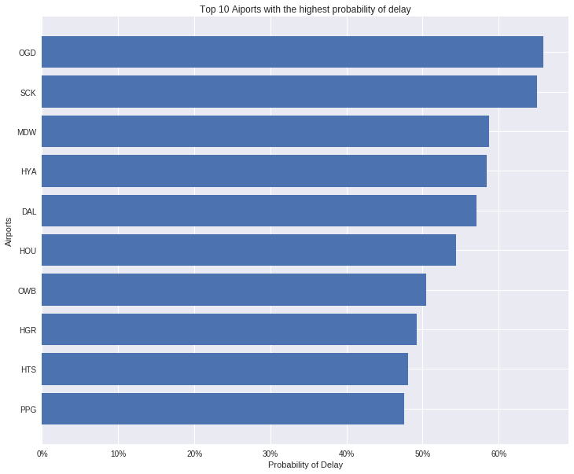

```python
final_prob = final_prob.reset_index()

final_prob.sort_values(by=['PROBABILITY'], inplace=True)

perc = []
for i in range(7):
    perc.append(str(i*10)+'%')

# Top 10 airports with the highest probability of delay
top10 = final_prob[-10:]

fig, ax = plt.subplots()

ax.set_ylabel('Airports')
ax.set_xlabel('Probability of Delay')
ax.set_title('Top 10 Aiports with the highest probability of delay')

fig.set_size_inches(12, 10)
ax.set_xticklabels(perc)

ax.barh(top10.ORIGIN, top10.PROBABILITY, align='center')
```

## "MISERY INDEX" for airlines

- A delayed flight can be caused due to many reasons like security issues, bad airport infrastracture, inappropriate weather, technical aircraft errors e.t.c.
- To create a Misery Index for the airlines, we are going to base our analysis on the `CARRIER DELAY` column.
- We are going to find the airlines that are making life difficult for passengers.

```python
len(flights.CARRIER.unique())
```

```
18
```

- It seems we have 18 different Carriers
- We are looking for the Total Flights per carrier.

```python
#how many flights per Carrier
grouped_carrier_flights = flights.groupby('CARRIER').size()

carrier_flights = pd.DataFrame(grouped_carrier_flights, columns=['total_flights'])

carrier_flights
```

| CARRIER | total_flights |
| --- | --- |
| 9E | 245917 |
| AA | 916818 |
| AS | 245761 |
| B6 | 305010 |
| DL | 949283 |
| EV | 202890 |
| F9 | 120035 |
| G4 | 96221 |
| HA | 83723 |
| MQ | 296001 |
| NK | 176178 |
| OH | 278457 |
| OO | 774137 |
| UA | 621565 |
| VX | 17670 |
| WN | 1352552 |
| YV | 215138 |
| YX | 316090 |

```python
#find the flights that had a delay
actual_delays = flights.loc[flights.CARRIER_DELAY > 0]

#hold only the columns that we are interested in
delays = actual_delays.loc[:, ['CARRIER', 'CARRIER_DELAY']]

grouped_delays = delays.groupby('CARRIER')

counted_delays = pd.DataFrame(grouped_delays.count())

counted_delays
```

| CARRIER | CARRIER_DELAY |
| --- | --- |
| 9E | 17291 |
| AA | 96337 |
| AS | 12416 |
| B6 | 55247 |
| DL | 65604 |
| EV | 17247 |
| F9 | 18816 |
| G4 | 9876 |
| HA | 7375 |
| MQ | 23155 |
| NK | 10304 |
| OH | 30304 |
| OO | 44202 |
| UA | 49043 |
| VX | 1166 |
| WN | 163911 |
| YV | 19022 |
| YX | 20836 |

So the only thing we have to do now is to merge

```python
carrier_prob = pd.merge(carrier_flights, counted_delays, on='CARRIER', how='inner')

carrier_prob = carrier_prob.CARRIER_DELAY / carrier_prob.total_flights

carrier_prob = pd.DataFrame(carrier_prob, columns=['DELAY_PROB'])

carrier_prob.sort_values(by=['DELAY_PROB'], inplace=True, ascending=False)

carrier_prob.head()
```

| CARRIER | DELAY_PROB |
| --- | --- |
| B6 | 0.181132 |
| F9 | 0.156754 |
| WN | 0.121186 |
| OH | 0.108828 |
| AA | 0.105078 |

- We now want to find the **average and median delay of each carrier**
- The dataframe grouped_delays is already created so we are going to use that

```python
more_carrier_stats = grouped_delays.agg(['mean', 'median'])

# Drop one level since we want to merge 2 df with the same level
more_carrier_stats.columns = more_carrier_stats.columns.droplevel()

more_carrier_stats.rename(columns={'mean': 'MEAN_DELAY', 'median': 'MEDIAN_DELAY'}, inplace=True)

more_carrier_stats
```

| CARRIER | MEAN_DELAY | MEDIAN_DELAY |
| --- | --- | --- |
| 9E | 51.227517 | 23.0 |
| AA | 38.773887 | 19.0 |
| AS | 43.478334 | 25.0 |
| B6 | 32.796460 | 15.0 |
| DL | 44.403832 | 18.0 |
| EV | 66.355366 | 27.0 |
| F9 | 36.818612 | 18.0 |
| G4 | 58.956561 | 23.0 |
| HA | 33.972610 | 19.0 |
| MQ | 34.160484 | 17.0 |
| NK | 40.012325 | 16.0 |
| OH | 33.348766 | 15.0 |
| OO | 80.612235 | 35.0 |
| UA | 38.866872 | 18.0 |
| VX | 45.530875 | 27.0 |
| WN | 25.354265 | 13.0 |
| YV | 55.892283 | 28.0 |
| YX | 38.667307 | 19.0 |

It's merging time. Let's tabulate

```python
total_carrier_stats = pd.merge(carrier_prob, more_carrier_stats, on='CARRIER', how='inner')

#Sorting by Delayed Probability
total_carrier_stats.sort_values(by=['DELAY_PROB'], ascending=False, inplace=True)

total_carrier_stats
```

| CARRIER | DELAY_PROB | MEAN_DELAY | MEDIAN_DELAY |
| --- | --- | --- | --- |
| B6 | 0.181132 | 32.796460 | 15.0 |
| F9 | 0.156754 | 36.818612 | 18.0 |
| WN | 0.121186 | 25.354265 | 13.0 |
| OH | 0.108828 | 33.348766 | 15.0 |
| AA | 0.105078 | 38.773887 | 19.0 |
| G4 | 0.102639 | 58.956561 | 23.0 |
| YV | 0.088418 | 55.892283 | 28.0 |
| HA | 0.088088 | 33.972610 | 19.0 |
| EV | 0.085007 | 66.355366 | 27.0 |
| UA | 0.078902 | 38.866872 | 18.0 |
| MQ | 0.078226 | 34.160484 | 17.0 |
| 9E | 0.070312 | 51.227517 | 23.0 |
| DL | 0.069109 | 44.403832 | 18.0 |
| VX | 0.065988 | 45.530875 | 27.0 |
| YX | 0.065918 | 38.667307 | 19.0 |
| NK | 0.058486 | 40.012325 | 16.0 |
| OO | 0.057098 | 80.612235 | 35.0 |
| AS | 0.050521 | 43.478334 | 25.0 |

We will now use the lookup table of the Dataset Documentation so we can include airline names in our results

```python
carrier_lookup = pd.read_csv('data/L_UNIQUE_CARRIERS.csv_')

carrier_lookup
```

|  | Code | Description |
| --- | --- | --- |
| 0 | 02Q | Titan Airways |
| 1 | 04Q | Tradewind Aviation |
| 2 | 05Q | Comlux Aviation, AG |
| 3 | 06Q | Master Top Linhas Aereas Ltd. |
| 4 | 07Q | Flair Airlines Ltd. |
| ... | ... | ... |
| 1660 | ZW | Air Wisconsin Airlines Corp |
| 1661 | ZX | Air Georgian |
| 1662 | ZX (1) | Airbc Ltd. |
| 1663 | ZY | Atlantic Gulf Airlines |
| 1664 | ZYZ | Skyway Aviation Inc. |

1665 rows × 2 columns

```python
#merging the 2 dfs
total_carrier_stats = pd.merge(total_carrier_stats, carrier_lookup, left_on='CARRIER', right_on='Code', how='left')

#prettifying the result
total_carrier_stats.set_index(total_carrier_stats.Code, inplace=True)
del total_carrier_stats['Code']
total_carrier_stats.rename(columns={'Description': 'CODE_DESC'}, inplace=True)
total_carrier_stats
```

| Code | DELAY_PROB | MEAN_DELAY | MEDIAN_DELAY | CODE_DESC |
| --- | --- | --- | --- | --- |
| B6 | 0.181132 | 32.796460 | 15.0 | JetBlue Airways |
| F9 | 0.156754 | 36.818612 | 18.0 | Frontier Airlines Inc. |
| WN | 0.121186 | 25.354265 | 13.0 | Southwest Airlines Co. |
| OH | 0.108828 | 33.348766 | 15.0 | PSA Airlines Inc. |
| AA | 0.105078 | 38.773887 | 19.0 | American Airlines Inc. |
| G4 | 0.102639 | 58.956561 | 23.0 | Allegiant Air |
| YV | 0.088418 | 55.892283 | 28.0 | Mesa Airlines Inc. |
| HA | 0.088088 | 33.972610 | 19.0 | Hawaiian Airlines Inc. |
| EV | 0.085007 | 66.355366 | 27.0 | ExpressJet Airlines LLC |
| UA | 0.078902 | 38.866872 | 18.0 | United Air Lines Inc. |
| MQ | 0.078226 | 34.160484 | 17.0 | Envoy Air |
| 9E | 0.070312 | 51.227517 | 23.0 | Endeavor Air Inc. |
| DL | 0.069109 | 44.403832 | 18.0 | Delta Air Lines Inc. |
| VX | 0.065988 | 45.530875 | 27.0 | Virgin America |
| YX | 0.065918 | 38.667307 | 19.0 | Republic Airline |
| NK | 0.058486 | 40.012325 | 16.0 | Spirit Air Lines |
| OO | 0.057098 | 80.612235 | 35.0 | SkyWest Airlines Inc. |
| AS | 0.050521 | 43.478334 | 25.0 | Alaska Airlines Inc. |

Let's plot it!

```
<BarContainer object of 18 artists>
```

[figure not shown]

```python
total_carrier_stats.sort_values(by=['DELAY_PROB'], inplace=True)

fig, ax = plt.subplots()

ax.set_ylabel('Carriers')
ax.set_xlabel('Probability of Delay')
ax.set_title('Top 10 Carriers with the highest probability of delay')


fig.set_size_inches(12, 10)

ax.barh(total_carrier_stats.CODE_DESC, total_carrier_stats.DELAY_PROB, align='center')

# total_carrier_stats.plot(x='CODE_DESC', y='DELAY_PROB', kind='barh', figsize=(12,10), grid=True)
```

# Distribution of Departures for Airports

- Here, we will take into consideration the 1% low flights outlier
- So, we have a dataframe containing the number of flight departures per airport (airport_flights)

```python
airport_flights
```

| ORIGIN | TOTAL_FLIGHTS |
| --- | --- |
| AKN | 63 |
| BKG | 71 |
| DLG | 84 |
| GST | 84 |
| HYA | 89 |
| ... | ... |
| CLT | 233317 |
| DEN | 235989 |
| DFW | 279298 |
| ORD | 332953 |
| ATL | 390046 |

354 rows × 1 columns

Let's find the maximun flight number

```python
max_flights = airport_flights.agg('max')
max_flights
```

```
TOTAL_FLIGHTS    390046
dtype: int64
```

We are going to plot the flights on a linear scale

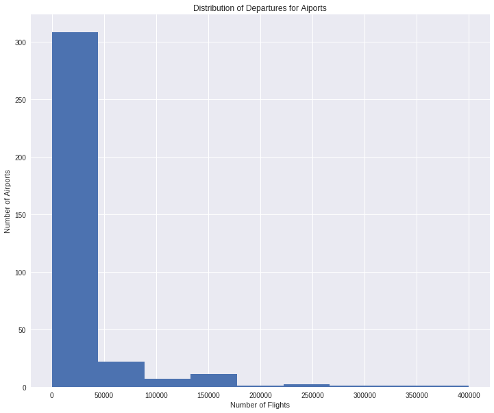

```python
fig, ax = plt.subplots()

ax.set_ylabel('Number of Airports')
ax.set_xlabel('Number of Flights')
ax.set_title('Distribution of Departures for Aiports')

fig.set_size_inches(12, 10)
_ = ax.hist(airport_flights.TOTAL_FLIGHTS, bins=np.linspace(0., 400000., 10))
```

- Yeah, there is not much to see here...
- That is because the airport flights distribution belongs to the [Power Law](https://en.wikipedia.org/wiki/Power_law) phenomenons.
- That's why we are going to plot it on a logarithmic scale.

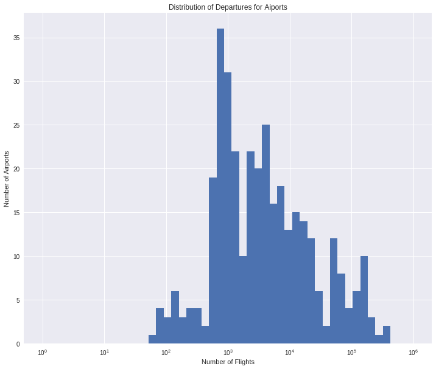

```python
#create 50 separate bins
bins = np.logspace(0, 6, num=50)
bins = np.insert(bins, 0, 0)

fig, ax = plt.subplots()

ax.set_ylabel('Number of Airports')
ax.set_xlabel('Number of Flights')
ax.set_title('Distribution of Departures for Aiports')
plt.xscale('log')
fig.set_size_inches(12, 10)

_ = ax.hist(airport_flights.TOTAL_FLIGHTS, bins=bins)
```

# Temporal Distribution of Delays

We are interested in the temporal distribution of delays, so we are going to create a plot that shows the number of flights and the number of delayed flights per month of year.

```python
#group by month
monthly_flights = pd.DataFrame(flights.groupby(flights.FL_DATE.dt.month).size(), columns=['TOTAL_FLIGHTS'])

monthly_flights.head()
```

| FL_DATE | TOTAL_FLIGHTS |
| --- | --- |
| 1 | 570118 |
| 2 | 520731 |
| 3 | 611987 |
| 4 | 596046 |
| 5 | 616529 |

```python
total_delays = flights.loc[flights.DEP_DELAY > 0]

delay_flights = pd.DataFrame(total_delays.groupby(total_delays.FL_DATE.dt.month).size(), columns=['TOTAL_FLIGHT_DELAYS'])

delay_flights.head()
```

| FL_DATE | TOTAL_FLIGHT_DELAYS |
| --- | --- |
| 1 | 183723 |
| 2 | 174962 |
| 3 | 199775 |
| 4 | 193204 |
| 5 | 215382 |

You know what time is it? It's **MERGE TIME**

```python
distribution = pd.merge(monthly_flights, delay_flights, on='FL_DATE', how='inner')
distribution
```

| FL_DATE | TOTAL_FLIGHTS | TOTAL_FLIGHT_DELAYS |
| --- | --- | --- |
| 1 | 570118 | 183723 |
| 2 | 520731 | 174962 |
| 3 | 611987 | 199775 |
| 4 | 596046 | 193204 |
| 5 | 616529 | 215382 |
| 6 | 626193 | 238353 |
| 7 | 645299 | 246392 |
| 8 | 644673 | 239323 |
| 9 | 585749 | 167257 |
| 10 | 616101 | 187187 |
| 11 | 586178 | 201256 |
| 12 | 593842 | 202403 |

We are going to create a `BarPlot`

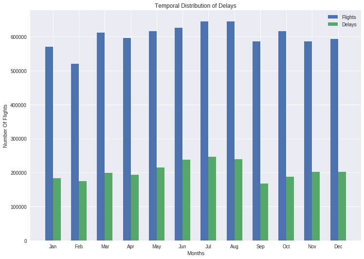

```python
import calendar

datelist = []
for month_idx in range(1, 13):
    datelist.append(calendar.month_abbr[month_idx])

plt.style.use('seaborn')

fig, ax = plt.subplots()
x = np.arange(len(datelist))  # the label locations
width = 0.30
rects1 = ax.bar(x - width/2, distribution.TOTAL_FLIGHTS, width, label='Flights')
rects2 = ax.bar(x + width/2, distribution.TOTAL_FLIGHT_DELAYS, width, label='Delays')

ax.set_ylabel('Number Of Flights')
ax.set_xlabel('Months')
ax.set_title('Temporal Distribution of Delays')
ax.set_xticks(x)
ax.set_xticklabels(datelist)
ax.legend()

fig.set_size_inches(10.5, 7.5)
fig.tight_layout()

plt.show()
```

# Which airline has the best performance?

We will create a table that shows, for each possible origin and destination, which airline has the best performance, in terms of mean departure delay.

Let's create a sorted MultiIndex

```python
#select specific columns of the dataset
short_flights = flights.loc[:, ['ORIGIN', 'DEST', 'CARRIER','DEP_DELAY']]

#create a MultiIndex
origin_dest = short_flights.set_index(['ORIGIN', 'DEST', 'CARRIER'])

#sort the Index
origin_dest.sort_index(inplace=True)

#keep the positive delays
origin_dest = origin_dest.loc[origin_dest.DEP_DELAY > 0]

#find the mean flight delay for each carrier
mean_origin_dest = origin_dest.groupby(['ORIGIN', 'DEST', 'CARRIER']).agg(['mean'])

mean_origin_dest
```

| ORIGIN | DEST | CARRIER | DEP_DELAY mean |
| --- | --- | --- | --- |
| ABE | ATL | 9E | 53.771429 |
|  |  | DL | 58.046154 |
|  |  | EV | 40.976190 |
|  | CLT | OH | 35.364706 |
|  | DTW | OO | 72.098425 |
| ... | ... | ... | ... |
| YAK | CDV | AS | 31.888889 |
|  | JNU | AS | 23.195652 |
| YNG | PIE | G4 | 111.000000 |
|  | SFB | G4 | 15.000000 |
| YUM | PHX | OO | 28.715415 |

12692 rows × 1 columns

- Now we need to find the **CARRIER** the minimum delay flight for each flight route.
- What we can do is to create a new column that also holds the carrier and find the min for each flight group

```python
#create a new column that also holds the Carrier, same as the Index but now is also a column
mean_origin_dest['CARRIER'] = mean_origin_dest.index.get_level_values('CARRIER')

#find the minimun value for each flight route
min_mean_origin_dest = mean_origin_dest.groupby(['ORIGIN', 'DEST']).min()

min_mean_origin_dest.columns = min_mean_origin_dest.columns.droplevel()

columns = ['MEAN_DEP_DELAY', 'CARRIER']

min_mean_origin_dest.columns = columns

columns = ['MEAN_DEP_DELAY', 'CARRIER']

min_mean_origin_dest.columns = columns

min_mean_origin_dest
```

[output not shown]

6311 rows × 2 columns

- We want a user friendly answer for the Carrier names.
- Here, we will showcase another way of obtaining this information
- We can achieve that by grabbing the names of the CARRIERS from the [FAA Operations & Performance Data](https://aspmhelp.faa.gov/index.php/ASQP:_Carrier_Codes_and_Names) website.

Let's try and read the page that contains the information we need

```python
try:
    r = requests.get("https://aspmhelp.faa.gov/index.php/ASQP:_Carrier_Codes_and_Names")
except requests.exceptions.HTTPError as he:
    print(he)
except requests.exceptions.ConnectionError as ce:
    print(ce)
print(r.content)
```

```
b'<!DOCTYPE html>\n<html lang="en" dir="ltr" class="client-nojs">\n<head>\n<title>ASQP: Carrier Codes and Names - ASPMHelp</title>\n<meta charset="UTF-8" />\n<meta name="generator" content="MediaWiki 1.21.1" />\n<link rel="shortcut icon" href="/favicon.ico" />\n<link rel="search" type="application/o…
```

Time for some cooking... In today's menu we have **Flights soup**.

The soup's ingridients are all the html tags for the page, including the table with the Carrier's codes and names.

```python
html = r.content
soup = BeautifulSoup(html, 'html.parser')
soup
```

[output not shown]

[output cut: 456 more lines]

[output not shown]

We will parse the html and collect the data

```python
table = soup.find("table")

rows = table.findAll('tr')

final_list = []
intermediate_list = []

for tr in rows:
    for td in tr.findAll("td"):
        intermediate_list.append(td.findNext(text=True).strip())
    ## finds every element inside the table
    final_list.append(intermediate_list)
    intermediate_list = []

data = final_list

data[:5]
```

```
[[],
 ['ZW', 'AWI', 'Air Wisconsin'],
 ['AS', 'ASA', 'Alaska Airlines'],
 ['G4', 'AAY', 'Allegiant Air LLC'],
 ['AA', 'AAL', 'American Airlines']]
```

Let's create a DataFrame out of that data

```python
car_names = pd.DataFrame(data, columns=['CARRIER', 'CARRIER_CODE', 'CARRIER_NAME'])

#delete first row
car_names = car_names.drop(0)

car_names.index = car_names.CARRIER

#delete columns that are not needed
car_names.drop(car_names.columns[[0,1]], axis=1,inplace=True)

car_names.head()
```

| CARRIER | CARRIER_NAME |
| --- | --- |
| ZW | Air Wisconsin |
| AS | Alaska Airlines |
| G4 | Allegiant Air LLC |
| AA | American Airlines |
| C5 | Champlain Air |

We can now join the Name column with the `min_mean_origin_dest` dataframe

```python
best_carrier = min_mean_origin_dest.join(car_names, on='CARRIER')

best_carrier
```

| ORIGIN | DEST | MEAN_DEP_DELAY | CARRIER | CARRIER_NAME |
| --- | --- | --- | --- | --- |
| ABE | ATL | 40.976190 | 9E | Endeavor Air |
|  | CLT | 35.364706 | OH | Jetstream Intl |
|  | DTW | 72.098425 | OO | Skywest Airlines |
|  | FLL | 55.574074 | G4 | Allegiant Air LLC |
|  | MDT | 175.000000 | OO | Skywest Airlines |
| ... | ... | ... | ... | ... |
| YAK | CDV | 31.888889 | AS | Alaska Airlines |
|  | JNU | 23.195652 | AS | Alaska Airlines |
| YNG | PIE | 111.000000 | G4 | Allegiant Air LLC |
|  | SFB | 15.000000 | G4 | Allegiant Air LLC |
| YUM | PHX | 28.715415 | OO | Skywest Airlines |

6311 rows × 3 columns

Let's check if we have any missing values

```python
best_carrier.isna().sum()
```

```
MEAN_DEP_DELAY    0
CARRIER           0
CARRIER_NAME      0
dtype: int64
```

Luckily we don't!

We will create a function that will determine **the best Carrier** for a particular pair of origin and destination airport.

```python
def select_min(df, orig, dest):
    res =  df.loc[orig, dest]
    return res.CARRIER_NAME
```

Let's try the function for **Lehigh Valley International Airport** in Penny with the **Atlanta Airport Shuttle** in Atlanta and see who is the **Master Carrier** for this particular flight route

```python
select_min(best_carrier, 'ABE', 'ATL')
```

```
'Endeavor Air'
```

Another example for this function. Let's put **Northwest Arkansas Regional Airport** in Bentonville with the **O'Hare** in Chicago and see who is the **Master Carrier** for this particular flight route.

```python
select_min(best_carrier, 'XNA', 'ORD')
```

```
'American Airlines'
```